# Used_Cars Dataset Exploration

## Introduction

> This document explore Used_Cars Dataset consist 7906 observations of used cars in some of the USA cities which were enlisted for sales with 18 features of the used cars. Some of the features are selling price, maximum power, transmission, year of purchase.

## Preliminary Wrangling

```python
# import all packages and set plots to be embedded inline
import numpy as np
import pandas as pd
import matplotlib.pyplot as plt
import seaborn as sb

%matplotlib inline
```

#### load dataset and view

```python
used_cars = pd.read_csv('UserCarData.csv')
used_cars.sample(10)
```

|  | Sales_ID | name | year | selling_price | km_driven | Region | State or Province | City | fuel | seller_type | transmission | owner | mileage | engine | max_power | torque | seats | sold |
| --- | --- | --- | --- | --- | --- | --- | --- | --- | --- | --- | --- | --- | --- | --- | --- | --- | --- | --- |
| 1823 | 1878 | Ford | 2017 | 889000 | 25000 | Central | Indiana | Lafayette | Petrol | Individual | Manual | First_Owner | 17.00 | 1497 | 121.31 | 150Nm@ 4500rpm | 5 | Y |
| 1697 | 1749 | Toyota | 2017 | 2950000 | 50000 | Central | Illinois | Woodridge | Diesel | Individual | Automatic | First_Owner | 15.04 | 2755 | 174.50 | 450Nm@ 1600-2400rpm | 7 | Y |
| 4690 | 4827 | Toyota | 2017 | 625000 | 25538 | West | Washington | Puyallup | Petrol | Trustmark_Dealer | Manual | First_Owner | 16.78 | 1496 | 88.73 | 132Nm@ 3000rpm | 5 | N |
| 702 | 723 | Mahindra | 2012 | 400000 | 120000 | East | Pennsylvania | Philadelphia | Diesel | Individual | Manual | First_Owner | 15.96 | 2523 | 62.10 | 195Nm@ 1400-2200rpm | 7 | Y |
| 6642 | 6831 | Ford | 2012 | 190000 | 112000 | Central | Missouri | University City | Diesel | Individual | Manual | Second_Owner | 20.00 | 1399 | 68.00 | 160Nm@ 2000rpm | 5 | N |
| 1583 | 1632 | Renault | 2014 | 495000 | 175000 | West | Washington | Mount Vernon | Diesel | Individual | Manual | First_Owner | 19.01 | 1461 | 108.45 | 248Nm@ 2250rpm | 5 | Y |
| 486 | 501 | Maruti | 2016 | 660000 | 34000 | Central | Texas | Dallas | Petrol | Individual | Manual | Second_Owner | 17.50 | 1373 | 91.10 | 130Nm@ 4000rpm | 7 | Y |
| 2872 | 2967 | Maruti | 2019 | 600000 | 18000 | East | New Hampshire | Salem | Petrol | Individual | Manual | First_Owner | 21.21 | 1197 | 81.80 | 113Nm@ 4200rpm | 5 | N |
| 7520 | 7737 | Tata | 2012 | 132000 | 82507 | West | Utah | Lehi | Diesel | Dealer | Manual | First_Owner | 13.93 | 2179 | 138.03 | 320Nm@ 1700-2700rpm | 7 | N |
| 7176 | 7381 | Hyundai | 2017 | 300000 | 10000 | West | California | San Jose | Petrol | Individual | Manual | First_Owner | 21.10 | 814 | 55.20 | 74.5Nm@ 4000rpm | 5 | N |

> the variable names is inconsistence of letter case and need to be changed to lower case letters for consistency

```python
# check the dataset information
print(f'(row, column) is {used_cars.shape} respectively\n')
used_cars.info()
```

```
(row, column) is (7906, 18) respectively

<class 'pandas.core.frame.DataFrame'>
RangeIndex: 7906 entries, 0 to 7905
Data columns (total 18 columns):
 #   Column             Non-Null Count  Dtype
---  ------             --------------  -----
 0   Sales_ID           7906 non-null   int64
 1   name               7906 non-null   object
 2   year               7906 non-null   int64
 3   selling_price      7906 non-null   int64
 4   km_driven          7906 non-null   int64
 5   Region             7906 non-null   object
 6   State or Province  7906 non-null   object
 7   City               7906 non-null   object
 8   fuel               7906 non-null   object
 9   seller_type        7906 non-null   object
 10  transmission       7906 non-null   object
 11  owner              7906 non-null   object
 12  mileage            7906 non-null   float64
 13  engine             7906 non-null   int64
 14  max_power          7906 non-null   float64
 15  torque             7906 non-null   object
 16  seats              7906 non-null   int64
 17  sold               7906 non-null   object
dtypes: float64(2), int64(6), object(10)
memory usage: 1.1+ MB
```

> there are no missing values but this will be confirmed in the below cell  
> the dataset consist of 7906 observations and 18 features ( 7906 rows, 18 columns)  
> for my analysis, I will drop some columns and change some datatypes later on.

#### lets confirm the missing values

```python
# check for missing values
used_cars.isna().sum()
```

```
Sales_ID             0
name                 0
year                 0
selling_price        0
km_driven            0
Region               0
State or Province    0
City                 0
fuel                 0
seller_type          0
transmission         0
owner                0
mileage              0
engine               0
max_power            0
torque               0
seats                0
sold                 0
dtype: int64
```

> using isna() function confirmed there are no missing values

#### next lets check for duplicated rows

```python
# check duplicated rows
used_cars.duplicated().sum()
```

```
0
```

> there are no duplicated rows in the dataset

#### next, lets check the number of unique observations in each columns

```python
# loop through variables to print unique values
list_var = ['Sales_ID', 'name', 'year', 'selling_price', 'km_driven', 'Region',
       'State or Province', 'City', 'fuel', 'seller_type', 'transmission',
       'owner', 'mileage', 'engine', 'max_power', 'torque', 'seats', 'sold']
for var in list_var:
    print(f'the unique observation(s) in {var}:\n{len(used_cars[var].value_counts())}\n')
```

```
the unique observation(s) in Sales_ID:
7906

the unique observation(s) in name:
31

the unique observation(s) in year:
27

the unique observation(s) in selling_price:
670

the unique observation(s) in km_driven:
898

the unique observation(s) in Region:
4

the unique observation(s) in State or Province:
49

the unique observation(s) in City:
1310

the unique observation(s) in fuel:
4

the unique observation(s) in seller_type:
3

the unique observation(s) in transmission:
2

the unique observation(s) in owner:
5

the unique observation(s) in mileage:
381

the unique observation(s) in engine:
121

the unique observation(s) in max_power:
318

the unique observation(s) in torque:
441

the unique observation(s) in seats:
9

the unique observation(s) in sold:
2
```

> variables that has unique names below 50 are (name, year, Region, state or province, fuel, seller_type, transmission, owner, seats, and sold)

#### next lets look at the list of unique observations of each of the variables/columns below 50

```python
# loop through variables to print unique values
list_var = ['name', 'year', 'Region', 'State or Province', 'fuel', 'seller_type', 'transmission', 'owner', 'seats', 'sold']
for var in list_var:
    print(f'the list of unique observations in {var}:\n{used_cars[var].unique()}\n')
```

```
the list of unique observations in name:
['Maruti' 'Skoda' 'Honda' 'Hyundai' 'Toyota' 'Ford' 'Renault' 'Mahindra'
 'Tata' 'Chevrolet' 'Datsun' 'Jeep' 'Mercedes' 'Mitsubishi' 'Audi'
 'Volkswagen' 'BMW' 'Nissan' 'Lexus' 'Jaguar' 'Land' 'MG' 'Volvo' 'Daewoo'
 'Kia' 'Fiat' 'Force' 'Ambassador' 'Ashok' 'Isuzu' 'Opel']

the list of unique observations in year:
[2014 2006 2010 2007 2017 2001 2011 2013 2005 2009 2016 2012 2002 2015
 2018 2019 2008 2020 1999 2000 2003 2004 1994 1998 1997 1995 1996]

the list of unique observations in Region:
['East' 'Central' 'West' 'South']

the list of unique observations in State or Province:
['District of Columbia' 'New York' 'Illinois' 'California' 'Texas'
 'Massachusetts' 'Washington' 'Georgia' 'North Carolina' 'Florida'
 'Pennsylvania' 'Michigan' 'Iowa' 'Oregon' 'New Mexico' 'Maryland'
 'Montana' 'Arkansas' 'Arizona' 'Maine' 'Vermont' 'New Jersey'
 'Connecticut' 'Oklahoma' 'Tennessee' 'Alabama' 'Wisconsin'
 'South Carolina' 'New Hampshire' 'Idaho' 'Minnesota' 'Ohio' 'Kansas'
 'Utah' 'Virginia' 'Nebraska' 'West Virginia' 'Colorado' 'Indiana'
 'Kentucky' 'Missouri' 'North Dakota' 'Rhode Island' 'Louisiana' 'Wyoming'
 'Nevada' 'Mississippi' 'Delaware' 'South Dakota']

the list of unique observations in fuel:
['Diesel' 'Petrol' 'LPG' 'CNG']

the list of unique observations in seller_type:
['Individual' 'Dealer' 'Trustmark_Dealer']

the list of unique observations in transmission:
['Manual' 'Automatic']

the list of unique observations in owner:
['First_Owner' 'Second_Owner' 'Third_Owner' 'Fourth_Above_Owner'
 'Test_Drive_Car']

the list of unique observations in seats:
[ 5  4  7  8  6  9 10 14  2]

the list of unique observations in sold:
['Y' 'N']
```

> Fourth_Above_Owner will be renamed to Forth_Owner.  
> Test_Drive_Car were cars being tested by the intended buyer before buying to ascertain its conditions, this could be First/Second/Third Owner cars, hence I will be removing all Test_Drive_Car rows.  
> I will convert transmission, seller_type, fuel, and region datatypes from str to nominal category, group year, assign it to new variable (purchase_year) and convert purchase_year, seat, owner to ordinal category.

#### lets change all column names to lower case for consistency

```python
# change all columns name to lower case for consistency
used_cars.columns = used_cars.columns.str.lower()

# rename 'name','state or province' to be more descriptive
used_cars.rename(columns = {'name':'brand','state or province':'state'},inplace=True)

# to check
used_cars.head(0)
```

|  | sales_id | brand | year | selling_price | km_driven | region | state | city | fuel | seller_type | transmission | owner | mileage | engine | max_power | torque | seats | sold |
| --- | --- | --- | --- | --- | --- | --- | --- | --- | --- | --- | --- | --- | --- | --- | --- | --- | --- | --- |

#### extract first word from owner observations

```python
# split owner column variable and select only descriptive order (first,second,third,fourth)
used_cars['owner'] = used_cars.owner.apply(lambda x:x.split('_')[0])
used_cars.owner.unique()
```

```
array(['First', 'Second', 'Third', 'Fourth', 'Test'], dtype=object)
```

#### remove rows with Test observations

```python
# remove rows with Test in owner column
used_cars = used_cars.loc[used_cars['owner'] != "Test"]

used_cars.owner.unique()
```

```
array(['First', 'Second', 'Third', 'Fourth'], dtype=object)
```

#### drop sales_id, torque,sold column

```python
# # drop columns as said above
col_drop = ['sales_id','torque','sold']
used_cars.drop(columns = col_drop, inplace=True)
```

```python
# check for changes
used_cars.columns
```

```
Index(['brand', 'year', 'selling_price', 'km_driven', 'region', 'state',
       'city', 'fuel', 'seller_type', 'transmission', 'owner', 'mileage',
       'engine', 'max_power', 'seats'],
      dtype='object')
```

#### group year and convert year, seats, owner to ordinal category. brand, region, state, fuel, seller_type, transmission and city to nominal category

```python
# function to orderly categorize column observations
def ordinal_cat(colm,val, order = False):
    """
    This function takes three parameters and returns the category datatype
    col : column to convert is datatype
    val : column observations, could be a list
    order : bool, default is False
    """
    order_year = pd.api.types.CategoricalDtype(categories = val, ordered = order)
    used_cars[colm] = used_cars[colm].astype(order_year)
```

```python
# group the year
used_cars.loc[used_cars['year'].between(1994,1999), 'purchase_year'] = '1994-1999'
used_cars.loc[used_cars['year'].between(2000,2009), 'purchase_year'] = '2000-2009'
used_cars.loc[used_cars['year'].between(2010,2019), 'purchase_year'] = '2010-2019'
used_cars.loc[used_cars['year']==2020, 'purchase_year'] = '2020'

# print to check if changes is effected
print(f'list of unique categories in purchase_year column is:\n{used_cars.purchase_year.unique()}')
```

```
list of unique categories in purchase_year column is:
['2010-2019' '2000-2009' '2020' '1994-1999']
```

```python
# ordered lists
year_list = ['1994-1999', '2000-2009', '2010-2019', '2020']
seats_list = [2, 4, 5, 6, 7, 8, 9, 10, 14]
owner_list = ['First', 'Second', 'Third', 'Fourth']

# non ordered lists
brand_list = list(used_cars.brand.unique())
region_list = list(used_cars.region.unique())
state_list = list(used_cars.state.unique())
fuel_list = list(used_cars.fuel.unique())
seller_list = list(used_cars.seller_type.unique())
trans_list = list(used_cars.transmission.unique())
city_list = list(used_cars.city.unique())
```

```python
# 2D array ordered lists with respect to col1 list order
col1_list = ['purchase_year', 'seats', 'owner']
ordered_list = [year_list, seats_list, owner_list]

# non ordered lists with respect to the col2_list order
unordered_list = [brand_list, region_list, state_list, fuel_list, seller_list, trans_list, city_list]
col2_list = ['brand', 'region', 'state', 'fuel', 'seller_type', 'transmission', 'city']
```

```python
# loop to convert ordered lists to ordinal categorical variable
for col1 in range(len(col1_list)):
    ordinal_cat(col1_list[col1], ordered_list[col1], order=True)

#loop to  convert unordered lists to nominal categorical variable
for col2 in range(len(col2_list)):
    ordinal_cat(col2_list[col2], unordered_list[col2])
```

```python
# check for changes
print(f'unique values in owner is: {used_cars.owner.unique()}')
print(f'unique values in seats is: {used_cars.seats.unique()}')
print('--------------------------')
used_cars.info()
```

```
unique values in owner is: ['First', 'Second', 'Third', 'Fourth']
Categories (4, object): ['First' < 'Second' < 'Third' < 'Fourth']
unique values in seats is: [5, 4, 7, 8, 6, 9, 10, 14, 2]
Categories (9, int64): [2 < 4 < 5 < 6 ... 8 < 9 < 10 < 14]
--------------------------
<class 'pandas.core.frame.DataFrame'>
Int64Index: 7901 entries, 0 to 7905
Data columns (total 16 columns):
 #   Column         Non-Null Count  Dtype
---  ------         --------------  -----
 0   brand          7901 non-null   category
 1   year           7901 non-null   int64
 2   selling_price  7901 non-null   int64
 3   km_driven      7901 non-null   int64
 4   region         7901 non-null   category
 5   state          7901 non-null   category
 6   city           7901 non-null   category
 7   fuel           7901 non-null   category
 8   seller_type    7901 non-null   category
 9   transmission   7901 non-null   category
 10  owner          7901 non-null   category
 11  mileage        7901 non-null   float64
 12  engine         7901 non-null   int64
 13  max_power      7901 non-null   float64
 14  seats          7901 non-null   category
 15  purchase_year  7901 non-null   category
dtypes: category(10), float64(2), int64(4)
memory usage: 563.6 KB
```

#### overall dataset statistical view

```python
# descriptive statistics view
used_cars.describe(include='all').T
```

|  | count | unique | top | freq | mean | std | min | 25% | 50% | 75% | max |
| --- | --- | --- | --- | --- | --- | --- | --- | --- | --- | --- | --- |
| brand | 7901 | 31 | Maruti | 2367 | NaN | NaN | NaN | NaN | NaN | NaN | NaN |
| year | 7901.0 | NaN | NaN | NaN | 2013.980762 | 3.862856 | 1994.0 | 2012.0 | 2015.0 | 2017.0 | 2020.0 |
| selling_price | 7901.0 | NaN | NaN | NaN | 647438.080876 | 806361.882249 | 29999.0 | 270000.0 | 450000.0 | 690000.0 | 10000000.0 |
| km_driven | 7901.0 | NaN | NaN | NaN | 69223.185293 | 56793.308509 | 1.0 | 35000.0 | 60000.0 | 96000.0 | 2360457.0 |
| region | 7901 | 4 | Central | 2372 | NaN | NaN | NaN | NaN | NaN | NaN | NaN |
| state | 7901 | 49 | California | 901 | NaN | NaN | NaN | NaN | NaN | NaN | NaN |
| city | 7901 | 1310 | New York City | 196 | NaN | NaN | NaN | NaN | NaN | NaN | NaN |
| fuel | 7901 | 4 | Diesel | 4298 | NaN | NaN | NaN | NaN | NaN | NaN | NaN |
| seller_type | 7901 | 3 | Individual | 6563 | NaN | NaN | NaN | NaN | NaN | NaN | NaN |
| transmission | 7901 | 2 | Manual | 6864 | NaN | NaN | NaN | NaN | NaN | NaN | NaN |
| owner | 7901 | 4 | First | 5215 | NaN | NaN | NaN | NaN | NaN | NaN | NaN |
| mileage | 7901.0 | NaN | NaN | NaN | 19.421449 | 4.036465 | 0.0 | 16.78 | 19.3 | 22.32 | 42.0 |
| engine | 7901.0 | NaN | NaN | NaN | 1458.531958 | 503.994359 | 624.0 | 1197.0 | 1248.0 | 1582.0 | 3604.0 |
| max_power | 7901.0 | NaN | NaN | NaN | 91.542652 | 35.704798 | 32.8 | 68.05 | 82.0 | 102.0 | 400.0 |
| seats | 7901.0 | 9.0 | 5.0 | 6249.0 | NaN | NaN | NaN | NaN | NaN | NaN | NaN |
| purchase_year | 7901 | 4 | 2010-2019 | 6879 | NaN | NaN | NaN | NaN | NaN | NaN | NaN |

### What is the structure of your dataset?

> the Used_Cars dataset has **7906 cars with 18 features**. I changed the column names to lower case, renamed "name" to "brand", "state or province" to "state". Extract first word from "owner" column observations, then remove rows with "Test" observations. I moved on to convert "transmission", "seller_type", "fuel", and "region" columns to nominal categorical datatype. Also grouped years and asiigned it to a new variable "purchase_year" and convert it alongside with "seats", "owner" to ordinal categorical datatype.  
> Among the 18 features, 10 are categorical variables, 8 are numerical variables but after pre_wrangling the dataset, I now have 7901 rows and 16 columns of which 6 are numerical and 10 are categorical.

### What is/are the main feature(s) of interest in your dataset?

> my interest is figuring out the feature(s) that best predict the selling price of the used cars in the gathered dataset

### What features in the dataset do you think will help support your investigation into your feature(s) of interest?

> From the dataset, I expect max_power to have strong effect on the selling price (ideally, a car with better max_power should be expensive than cars with less max_power) though brand and other features like seats, mileage, km_driven, fuel, transmission, seller_type, owner, seats, and purchase_year are also expect to have effect on the selling_price but not as strong as max_power. I do not choose engine, region, state and city. mathematically, engine is proportional to max_power hence I expect both to positively correlate with each other. region, state and city are locations and variation in selling_price of used cars from one location is probably due to distance and considring cost of distance will equivalent offset selling price variation, moreover, there is no addional information like distance between cities/state/regions to investigate this.

#### check for correlation between max_power and engine to ascertain the observation in their relationship

```python
# chech for correlation
used_cars[['engine','max_power']].corr()
```

|  | engine | max_power |
| --- | --- | --- |
| engine | 1.000000 | 0.704307 |
| max_power | 0.704307 | 1.000000 |

> max_power and engine are correlated as expected, hence i would only consider max_power in my analysis

## Univariate Exploration

#### Firstly, lets examine the distribution of 'selling_price', using a histogram.

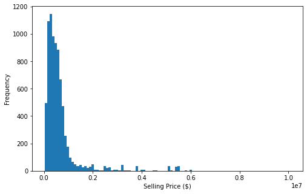

```python
# plot the price histogram chart
bin_size = 100500;
price_max = used_cars.selling_price.max()

bins = np.arange(29000,price_max + bin_size, bin_size)

plt.figure(figsize=[8,5])
plt.hist(data=used_cars, x='selling_price', bins=bins);
plt.xlabel('Selling Price ($)')
plt.ylabel('Frequency')
plt.show()
```

> It skewed right with most of the used cars sells at lower price, lets plot using log tansformation

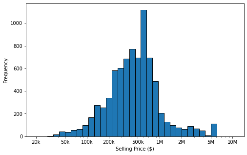

```python
# the above plot is right skewed with long tail, lets plot on log scale instead
bin_size = 0.08
log_price_max = np.log10(used_cars['selling_price']).max()
bins = 10 ** np.arange(4.3, log_price_max + bin_size, bin_size)

plt.figure(figsize=[8,5])
plt.hist(data=used_cars, x='selling_price', bins=bins, edgecolor='black')
plt.xscale('log')
plt.xticks([2e4, 5e4, 1e5, 2e5, 5e5, 1e6, 2e6, 5e6, 1e7], ['20k','50k','100k','200k','500k','1M', '2M','5M','10M'])
plt.xlabel('Selling Price ($)')
plt.ylabel('Frequency')
plt.show()
```

> there are more used cars with low price in the plot as it is skewed to the right with outliers. When plotted on a log-scale, the plot is a unimodal, almost symmetrical with peak aroud 650k USD. there is a spike in price around 450k USD and a spike at 5m USD. this could be due to other feature we will look into.

#### Next lets examine distribution of max_power

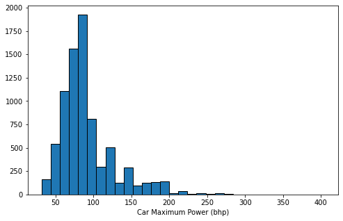

```python
# plot using large bin size
bin_size = 12
pwr_max = used_cars.max_power.max()
bins = np.arange(32,pwr_max + bin_size, bin_size)
plt.figure(figsize=[8,5])
plt.hist(data=used_cars, x='max_power',bins=bins, edgecolor='black')
plt.xlabel('Car Maximum Power (bhp)')
plt.show()
```

> it is skewed right just like the standard selling_price plot, most of the used cars were of low maximum power (55 - 85bhp). there are spike at around 120bhp and also at around 140bhp.

#### next lets examine distribution of mileage

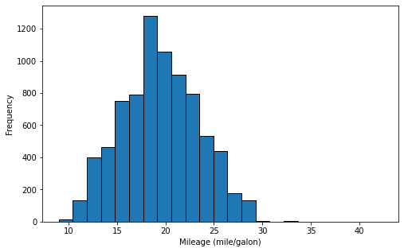

```python
bin_size = 1.45

log_eng_max = used_cars.mileage.max()
bins = np.arange(9, log_eng_max + bin_size, bin_size)

plt.figure(figsize=[8,5])
plt.hist(data=used_cars,x='mileage',bins=bins, edgecolor='black')

plt.xlabel('Mileage (mile/galon)')
plt.ylabel('Frequency')

plt.show()
```

> it is unimodal, roughly symmetrical with few datapoints above km/galon. most of the car mileage are between (15 and 23)km/galon with most frequent used cars around 18km/galon of mileage.

#### next lets examine distribution of km_driven

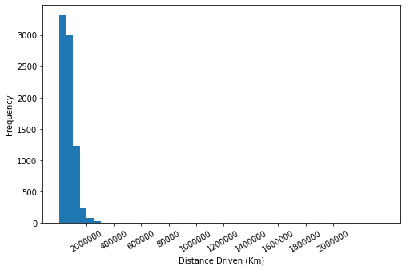

```python
bin_size = 50500

log_eng_max = used_cars.km_driven.max()
bins = np.arange(0, log_eng_max + bin_size, bin_size)

plt.figure(figsize=[8,5])
plt.hist(data=used_cars,x='km_driven',bins=bins)

plt.xticks([2e5, 4e5, 6e5,8e5, 1e6, 1.2e6, 1.4e6, 1.6e6, 1.8e6, 2e6],
           [2000000, 400000, 600000, 80000, 1000000, 1200000, 1400000, 1600000, 1800000, 2000000], rotation = 30)

plt.xlabel('Distance Driven (Km)')
plt.ylabel('Frequency')

plt.show()
```

> it is skewed right, lets zoom using xlim scaling

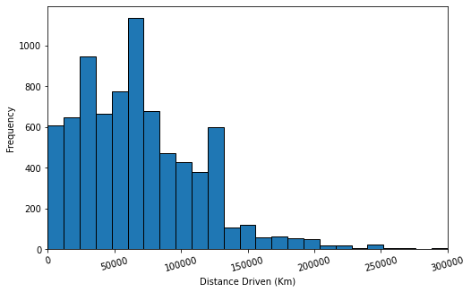

```python
bin_size = 12000

log_eng_max = used_cars.km_driven.max()
bins = np.arange(0, log_eng_max + bin_size, bin_size)

plt.figure(figsize=[8,5])
plt.hist(data=used_cars,x='km_driven',bins=bins, edgecolor='black')

plt.xticks([0, 5e4, 1e5, 1.5e5, 2e5, 2.5e5, 3e5, 3.5e5, 4e5, 4.5e5, 5e5],
           [0, 50000, 100000, 150000, 200000, 250000, 300000, 350000, 400000, 450000, 500000], rotation = 15)

plt.xlabel('Distance Driven (Km)')
plt.ylabel('Frequency')
plt.xlim(0,300000)

plt.show()
```

> it skewed right with peak around 70000Km and spike at around 30000km and another spike at 125000km. Most of the used cars were less driven.

#### next lets examine the frequency of fuel types

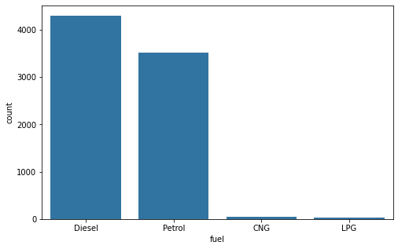

```python
plt.figure(figsize=[8,5])
color = sb.color_palette()[0]
order = used_cars.fuel.value_counts().index
sb.countplot(data=used_cars, x='fuel', color=color, order=order);
```

> most of the used cars were using Diesel and Petrol with Diesel fuel used cars being the highest

#### what transmission is frequent in the used cars

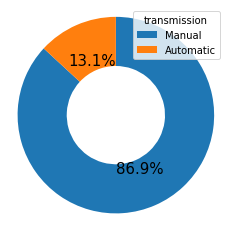

```python
textprops = {"fontsize":15}
trans_sorted = used_cars['transmission'].value_counts().reset_index()
labels = trans_sorted['index']
plt.pie(data=trans_sorted,x= 'transmission',labels=None, startangle = 90,
        counterclock = False, wedgeprops = {'width': 0.5}, autopct='%.1f%%',
       textprops = textprops)
plt.axis('square')
plt.legend(labels, title = 'transmission', loc='best');
```

> 86.9% of the used cars are using Manual transmission while 13.1% are automatic

#### Next seller_type frequency

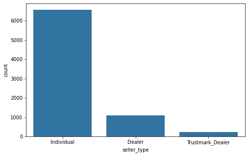

```python
plt.figure(figsize=[8,5])
color = sb.color_palette()[0]
order = used_cars.seller_type.value_counts().index
sb.countplot(data=used_cars, x='seller_type', color=color, order=order);
```

> most of the used cars sellers were individual seller

#### Next I will examine owner

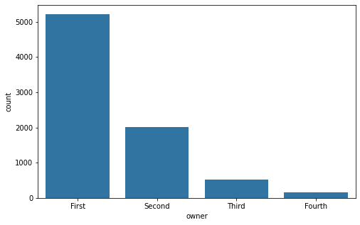

```python
plt.figure(figsize=[8,5])
color = sb.color_palette()[0]
sb.countplot(data=used_cars, x='owner', color=color)
plt.xticks(rotation = 0);
```

> most of the used cars were owned by first owner, followed by second owner, third owner fourth owner. this is interesting

#### lets examine seats

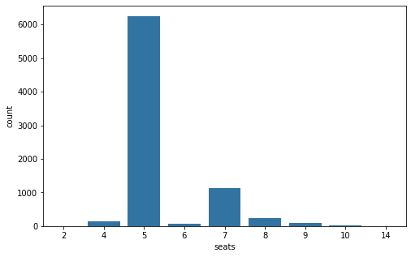

```python
plt.figure(figsize=[8,5])
color = sb.color_palette()[0]
sb.countplot(data=used_cars, x='seats', color=color);
```

> most of the used cars were 5 seaters

#### lets examine the year that is frequent in the purchased_year

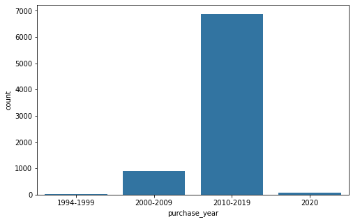

```python
plt.figure(figsize=[8,5])
color = sb.color_palette()[0]
sb.countplot(data=used_cars, x='purchase_year', color=color)
plt.xticks(rotation=0);
```

> it is interesting to see that used cars in the dataset increases as the purchased_year increases but dropped in year 2020. this could be due to old cars are phasing out and the dropped in 2020 reveals no much data being a present year of data colection possibly.however, most of the cars are purchase between year 2010 and 2019.

### Discuss the distribution(s) of your variable(s) of interest. Were there any unusual points? Did you need to perform any transformations?

> I plotted using standard scale and there are more used cars with low price in the plot as it is skewed to the right with outliers or probably less car with high selling price in the dataset. When plotted on a log-scale, the plot is a unimodal, almost symmetrical with peak aroud N650k. there is a spike in price around N450k and a spike at N5m. this could be due to other feature we will look into.

### Of the features you investigated, were there any unusual distributions? Did you perform any operations on the data to tidy, adjust, or change the form of the data? If so, why did you do this?

> km_driven skewed right and I used xlim scaling to zoom the km_driven plot for more view. It was seen that most of the used cars were less driven.

## Bivariate Exploration

> In this section, investigate relationships between pairs of variables in your data. Make sure the variables that you cover here have been introduced in some fashion in the previous section (univariate exploration).

```python
numeric_var = ['selling_price', 'mileage', 'km_driven', 'max_power']
categorical_var = ['purchase_year', 'fuel', 'seller_type', 'transmission', 'owner', 'seats']
```

#### lets investigate the pairwise correlation between numeric variable of interest

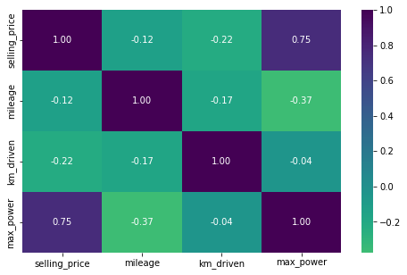

```python
plt.figure(figsize=[8,5])

sb.heatmap(used_cars[numeric_var].corr(), cmap='viridis_r', annot=True, fmt = '.2f', center=0);
```

> as expected, selling price and max_power are strongly correlated, km_driven are fairly correlated with selling price. mileage and selling price have weak corellation. the spread and more detail could be view using the scatterplot

#### lets invesigate more using scatterplot

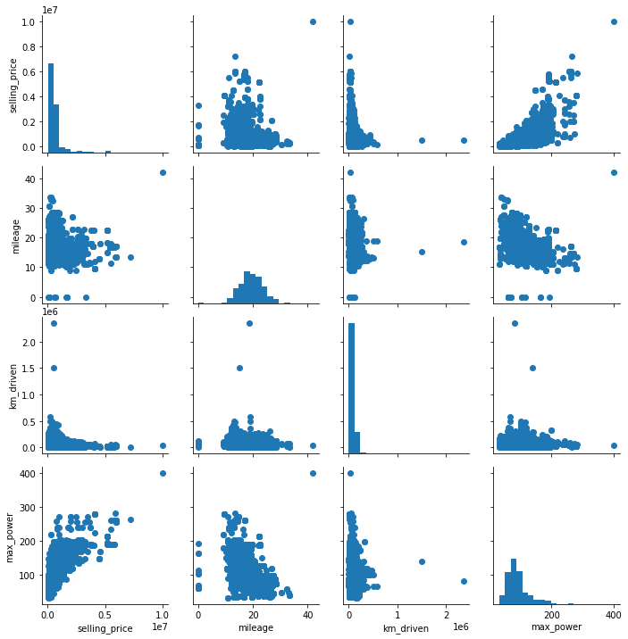

```python
# view the relationship using scatterplot
g = sb.PairGrid(data = used_cars, vars = numeric_var)
g = g.map_diag(plt.hist, bins = 20)
g.map_offdiag(plt.scatter);
```

> max_power and selling price are proportional.there are more data point between N29,999 and N4,000,000 on selling price, between 20 and 200bhp on max_power but disparsed as it increases. max_power and mileage are fairly negatively correlated. I will take a look at the max_power, km_driven and mileage next

#### Taking more look into the relationship between maximum power, engine km driven and mileage

#### max_power

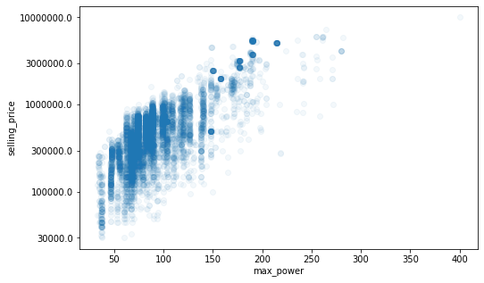

```python
def log_trans(x, inverse = False):
    if not inverse:
        return np.log10(x)
    else:
        return np.power(10, x)
plt.figure(figsize=[8,5])
sb.regplot(data=used_cars, x='max_power', y = used_cars['selling_price'].apply(log_trans),
           x_jitter=0.4, scatter_kws={"alpha":1/20}, fit_reg=False);
tick_locs = [3e4,1e5,3e5,1e6,3e6,1e7]
plt.yticks(log_trans(tick_locs), tick_locs);
```

> Maximum power and Selling price have strong relationship, The more maximum power of the car, the higher the selling price but this need to be visualized with other variable of interest in multivariate analysis

#### km_driven

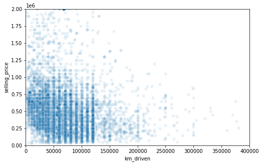

```python
plt.figure(figsize=[8,5])
sb.scatterplot(data=used_cars, x='km_driven', y = used_cars['selling_price'],alpha=1/10)
plt.xlim(0, 4e5)
plt.ylim(0, 2e6);
```

> Km driven has negative relatioship with the selling price but is fairly weak. the more the km_driven, the lesser the selling price

#### mileage

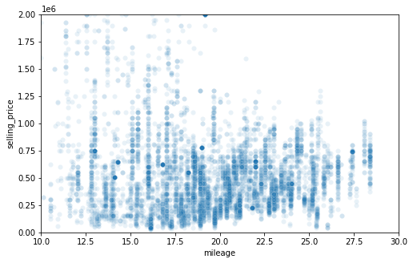

```python
plt.figure(figsize=[8,5])
sb.scatterplot(data=used_cars, x='mileage', y = used_cars['selling_price'],alpha=1/10)
plt.xlim(10, 30);
plt.ylim(0, 2e6);
```

> far weak negative correlated

```python
# functions to plot violin and boxplot with Pairplot
def violingrid156(x, y, **kwargs):
    """ for creating boxp with seaborn's PairGrid. """
    base_color = sb.color_palette()[0]
    sb.violinplot(x=x, y=y, inner='quartile', color=base_color)
    plt.gcf().set_size_inches(15, 6)

def violingrid155(x, y, **kwargs):
    """ for creating boxp with seaborn's PairGrid. """
    base_color = sb.color_palette()[0]
    sb.boxplot(x=x, y=y, color=base_color)
    plt.gcf().set_size_inches(15, 5)

def cat_plot(df, cat_x, var = None, rotate = 0, boxgrid=None):

    count = 0

    for cat in cat_x:
        g = sb.PairGrid(data =df , y_vars = var, x_vars = cat, height = 3, aspect = 1.5)
        g.map(boxgrid)
        count+=1
        if cat == 'brand':
            plt.xticks(rotation=rotate)
    plt.show();
```

#### lets examine the relationship between categorical variables and selling_price

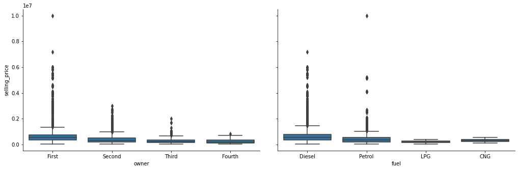

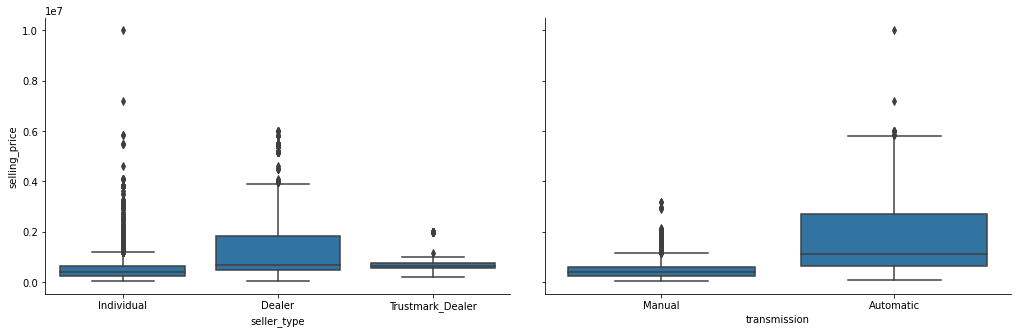

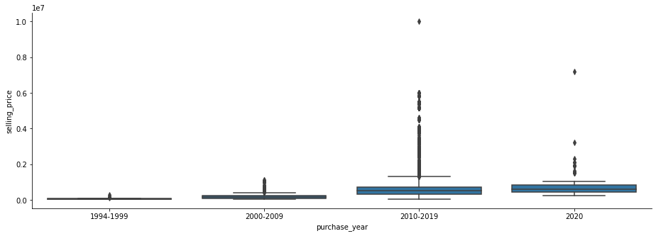

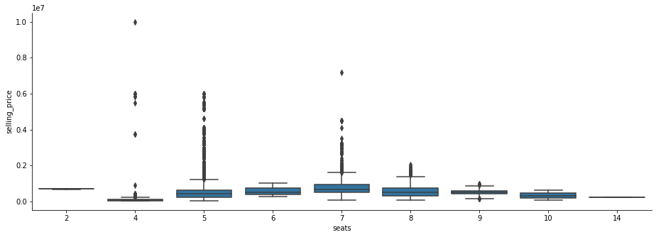

```python
cat_p = [['owner', 'fuel'], [ 'seller_type', 'transmission'], 'purchase_year', 'seats']
cat_plot(used_cars, cat_p, var='selling_price', rotate=50, boxgrid=violingrid155)
```

#### sorting based on peak selling_price for each column

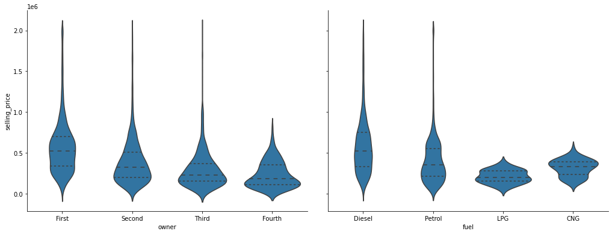

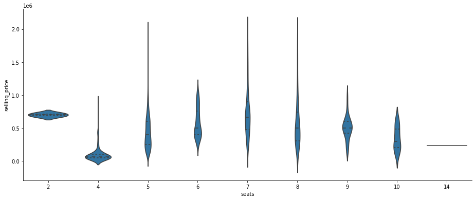

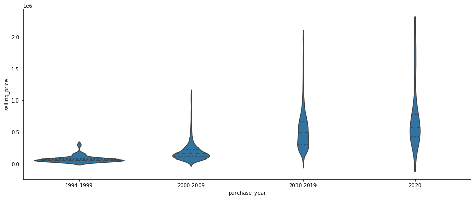

```python
# sorting for selling_price less than or equal to $2,000,000
price_2m = used_cars[used_cars['selling_price'] <= 2e6]

# plot for owner, fuel and seats
own_fuel_seat = [['owner', 'fuel'],'seats', 'purchase_year']
cat_plot(price_2m, own_fuel_seat, var='selling_price', boxgrid=violingrid156)
```

> there is relationship between owner and selling price as seen from the plot int the top left, the selling price depreciate as the used car is being used by first owner and then second owner till the third and fourth owner. the third and fourth owner have same range but the third has same peak of outliers.  
> fuel and selling price has a relationship. Diesel fuel used cars are more expensive than petrol. Petrol higher than CNG and LPG being the cheapest  
> no clear relationship on number of seats.  
> purchase year and selling price are positively related, as the purchase year become recent, the selling price appreciates.

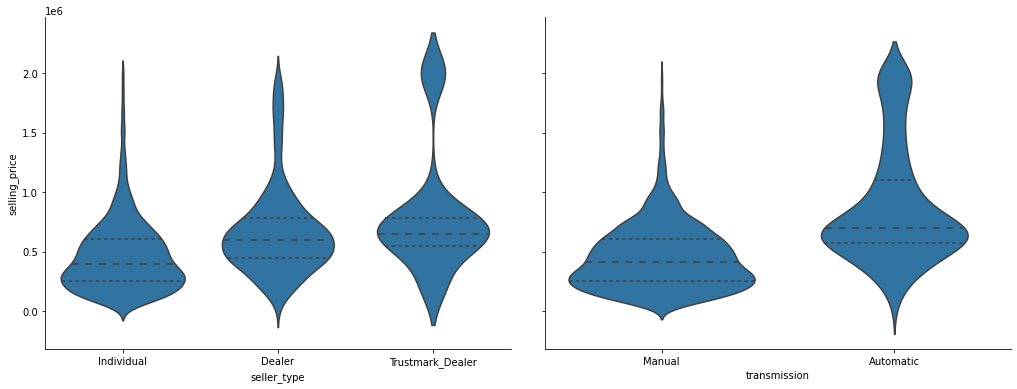

```python
# sorting for selling_price less than or equals $6,000,000
price_6m = used_cars[used_cars['selling_price'] <= 6e6]

# plot
own_fuel_seat = [['seller_type', 'transmission']]
cat_plot(price_2m, own_fuel_seat, var='selling_price', boxgrid=violingrid156)
```

> it is interesting to see that Trustmark Dealers and Dealers are of the same selling price range. However, cars enlisted for sales by DEALERs are more expensive than individuals  
> there is relationship between selling price and transmission. Automatic transmission cars are expensive than manual.

#### next lets see relationship between owner and purchase_year, seller_type, fuel, and transmission

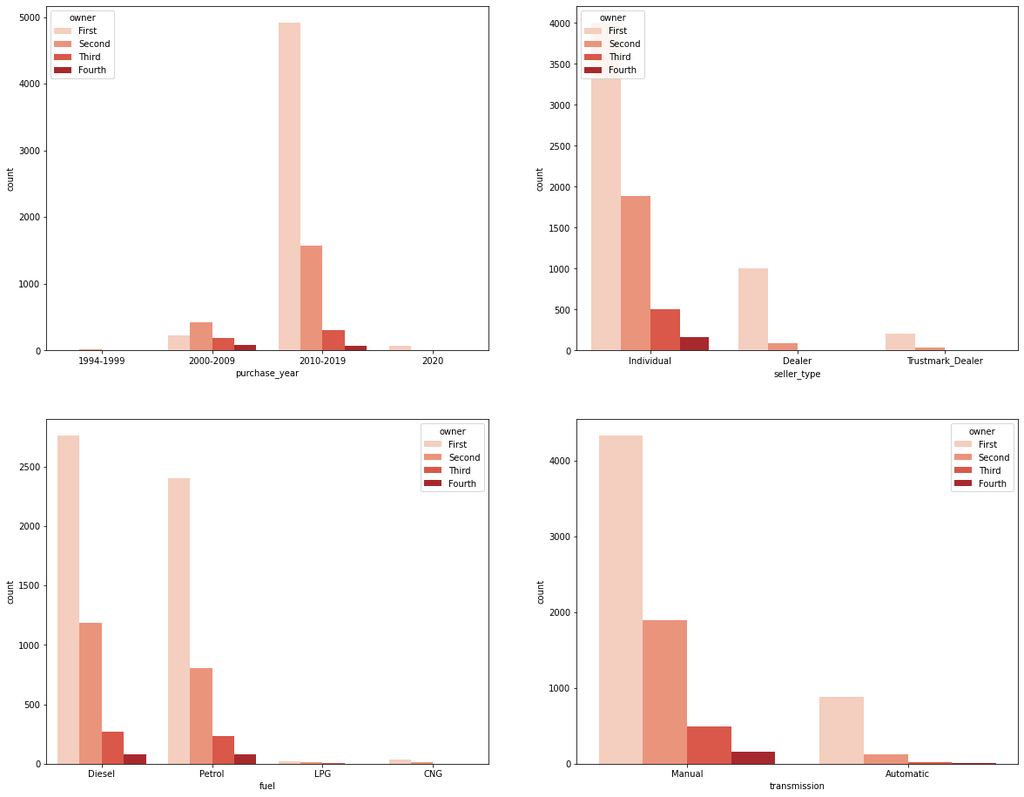

```python
fig, ax = plt.subplots(ncols = 2, nrows = 2 , figsize = [20,16])
catlist = ['purchase_year', 'seller_type', 'fuel', 'transmission']

r = c =  kount = 0
for i in catlist:
    if c > 1:
        r += 1
        c = 0
    if r == 2:
        break
    sb.countplot(data = used_cars, x = i, hue = 'owner', ax = ax[r,c],
               palette = 'Reds')
    kount+= 1
    c += 1
```

> most of the cars are purchased in year between 2010-2019, individual, uses diesel or petrol and are manual. it is observed in the top left plot that there was no first owner car in 1994, but in 200-2009, few are first owned and in 2010-2019, most of the cars are first owner cars. In 2020, all the cars are first owned but few data points  
> DEALERs enlisted only first and second owner for sale.  
> LPG are not used in fourth owner cars. CNG are recent cars as only first and second owner cars use it as type of fuel.

#### next is relationship between purchase_year and transmission, fuel, and seller_type

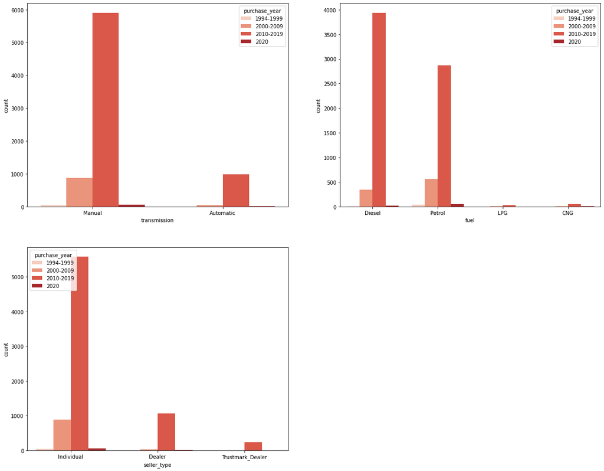

```python
fig, ax = plt.subplots(ncols = 2, nrows = 2 , figsize = [20,16])
catlist = ['transmission', 'fuel', 'seller_type']

r = c =  kount = 0
for i in catlist:
    if c > 1:
        r += 1
        c = 0
    if r == 3:
        break
    sb.countplot(data = used_cars, x = i, hue = 'purchase_year', ax = ax[r,c],
               palette = 'Reds')
    kount+= 1
    c += 1
fig.delaxes(ax[1][1])
```

> they are majorly purchase between year 2010-2019. most of the cars are manual, uses diesel or petrol and are individual.  
> automatic cars were not purchase in year 1994-1999  
> DEALERs does not sells cars that were purchase betweeen 1994-1999.

#### next is relationship between transmission and fuel

#### transmission and seller_type

#### seller_type and fuel

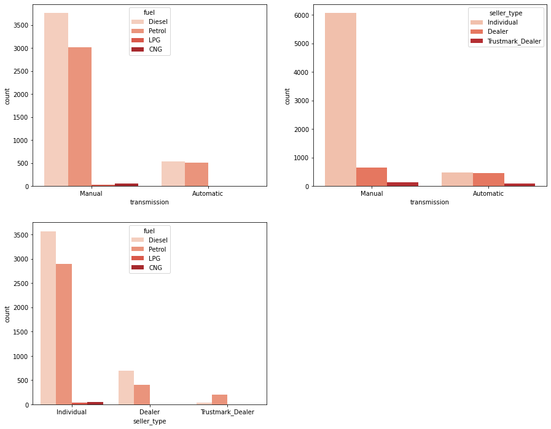

```python
plt.figure(figsize = [15, 12])
base_color = sb.color_palette()[0]
# left plot:
plt.subplot(2, 2, 1)
sb.countplot(data = used_cars, x = 'transmission', hue = 'fuel', palette = 'Reds');


# right plot:
plt.subplot(2, 2, 2)
sb.countplot(data = used_cars, x = 'transmission', hue = 'seller_type', palette = 'Reds');


# left plot:
plt.subplot(2, 2, 3)
sb.countplot(data = used_cars, x = 'seller_type', hue = 'fuel', palette = 'Reds',);
```

> most cars that uses petrol and diesel are manual, individual.  
> majority of manual cars are enlisted for sale by individual, individual and DEALERs have the same proportion of automatic cars  
> automatics cars uses only diesel or petrol and also cars enlisted for sale by DEALERs only uses diesel or petrol.

### Talk about some of the relationships you observed in this part of the investigation. How did the feature(s) of interest vary with other features in the dataset?

> selling price has strong positive correlation with max_power but faily negative correlated with km_driven and weak negative correlated with mileage. It is also observed that selling price increases as the purchase year increases. selling price, owner and year are related, as the owner of the car order from first to the fourth, the selling price decreases.

### Did you observe any interesting relationships between the other features (not the main feature(s) of interest)?

> max_power and mileage are fairly negatively correlated, it is interesting to see purchase year and owner related. recent purchase cars belongs to first owner and oldest purchase belongs to fouth owner.

## Multivariate Exploration

> Create plots of three or more variables to investigate your data even further. Make sure that your investigations are justified, and follow from your work in the previous sections.

#### I want to explore how variables of interest affects the selling price. starting with effect of owner on relationship between max_power and selling_price

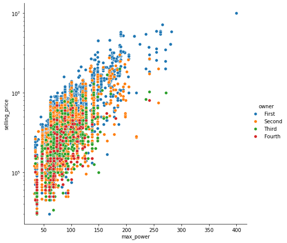

```python
g = sb.FacetGrid(data =used_cars, hue = 'owner', height = 7)
g.map(sb.scatterplot, 'max_power', 'selling_price');
plt.yscale('log')
g.add_legend();
```

> Individual owner has effect on relationship between selling_price and max_power. this show that owner has a strong positive relationship with selling price and car maximum power.

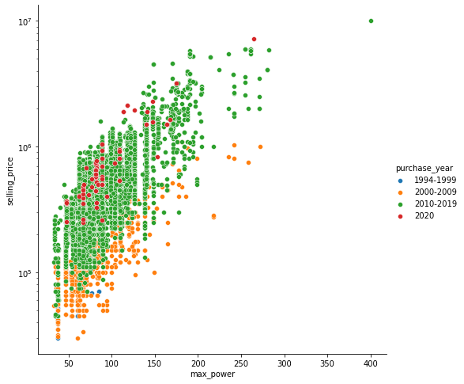

```python
g = sb.FacetGrid(data =used_cars, hue = 'purchase_year', height = 7)
g.map(sb.scatterplot, 'max_power', 'selling_price');
plt.yscale('log')
g.add_legend();
```

> the relationship starts from weak positive relationship to strong relationship between 1994 to 2020. but 2020 has few data points to depicts moore information. This shows that purchase year has effect on the relationship between selling price and maximum power of the cars

#### I will look at how transmission affects the relationship between selling price and max_power

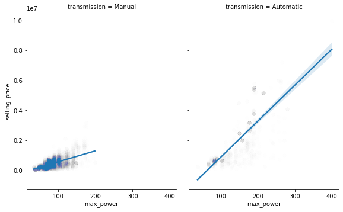

```python
g = sb.FacetGrid(data = used_cars, col = 'transmission', col_wrap = 4)
g.map(sb.regplot,'max_power', 'selling_price', x_jitter = 0.05, scatter_kws = {'alpha': 0.005});
plt.gcf().set_size_inches(16, 6)
```

> there are few automatics cars, however, tarnsmission has a strong relationship with selling price and maximum power as it stronger from manual cars to automatics cars. this depicts that transmission has effect on the relationship between selling_price and max_power

#### I will look at how fuel affects the relationship between selling price and max_power

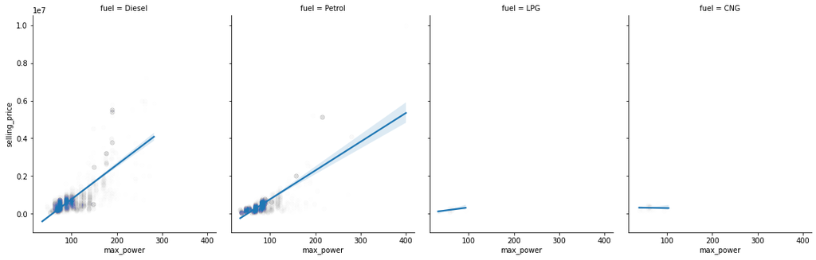

```python
g = sb.FacetGrid(data = used_cars, col = 'fuel', col_wrap = 4)
g.map(sb.regplot,'max_power', 'selling_price', x_jitter = 0.05, scatter_kws = {'alpha': 0.005});
plt.gcf().set_size_inches(16, 6)
```

> Individual fuel like Diesel and Petrol has strong positive effect on the relationship between selling price and maximum power of the used cars